# ANPP_Wheat_Basic

Celeste Basken

2026-01-27

# ANPP Wheat Biomass

```r
# Loading in data to explore
ANPP <- read.csv("Biomass/ANPP_Wheat_Weights.csv")

ANPP <- ANPP %>%
  mutate(
    Inoculation = factor(Inoculation),
    Polyculture = factor(Polyculture),
    Group = interaction(Inoculation, Polyculture, sep = "_")
  )
```

## Part 1: Pretty basic figures

Clustering without regard to PPT:

- Just a note here: I’m using Biomass_g_pp, which is grams per plant of wheat ANPP.

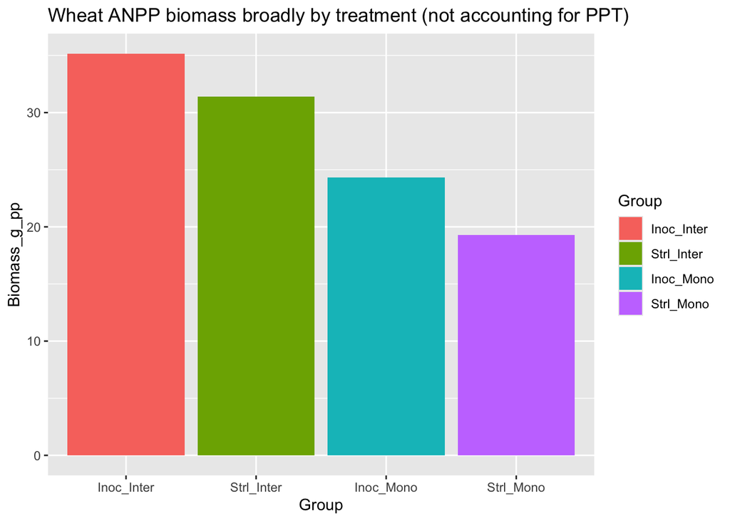

Takeaways

- Strl mono is still the smallest, like with the berries

The same data is below, but with each pot plotted so you can see the variation within the treatments:

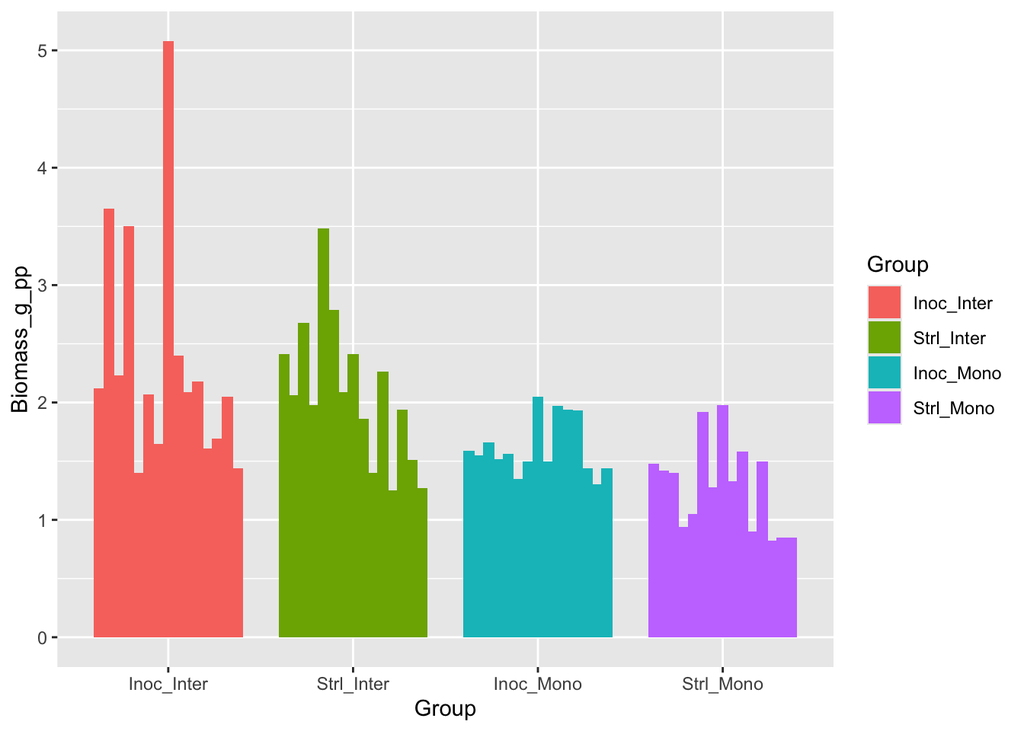

Takeaways * There is a large outlier potentially in the inoc_inter treatment

## Part 2: Looking at PPT and what the general behavior is

To begin, here’s what I would EXPECT the graph to look like:

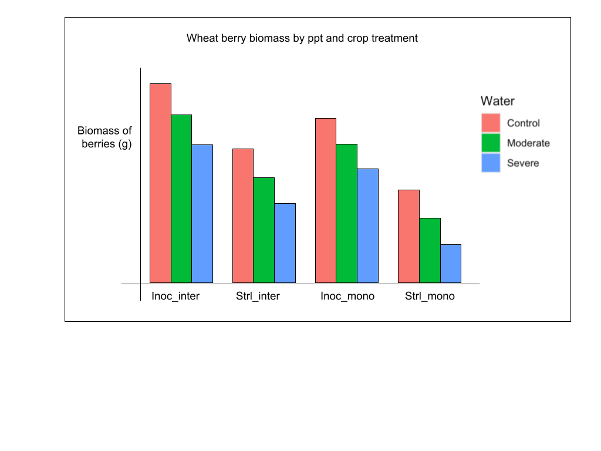

```r
knitr::include_graphics("Biomass/ANPP/expected.png")
```

Here’s the actual figure with the data:

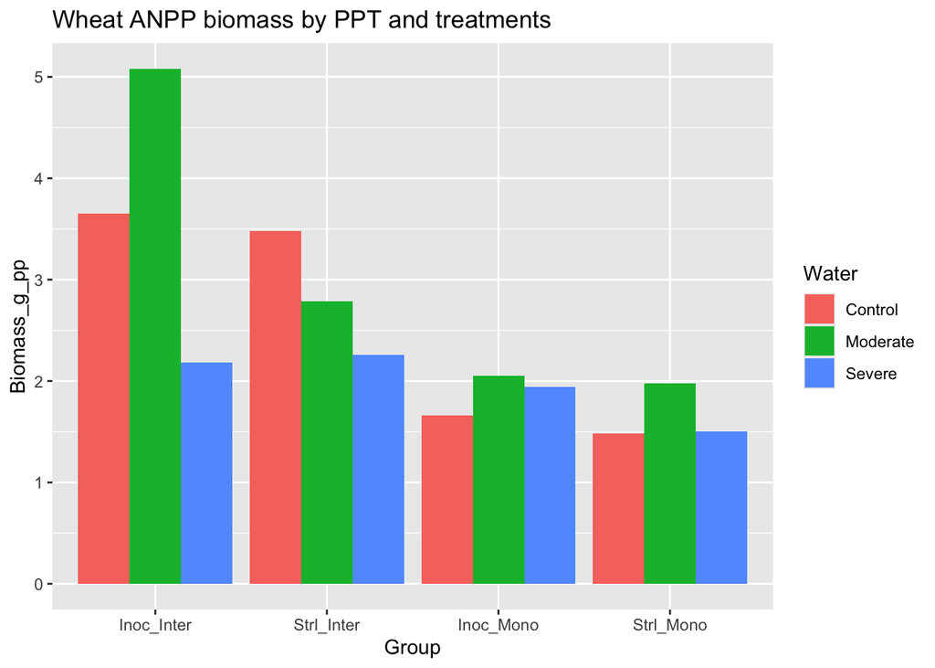

Takeaways

- Kind of all over the place
- Only strl_inter really makes sense?
- Curious if there is a large outlier in the inoc_inter group
- As compared to the berries, the drought seems to have affected ANPP much less for the wheat.

## Analyzing these ANPP biomass trends more in depth

All of the treatments together looking at water: both as a bar graph and boxplot

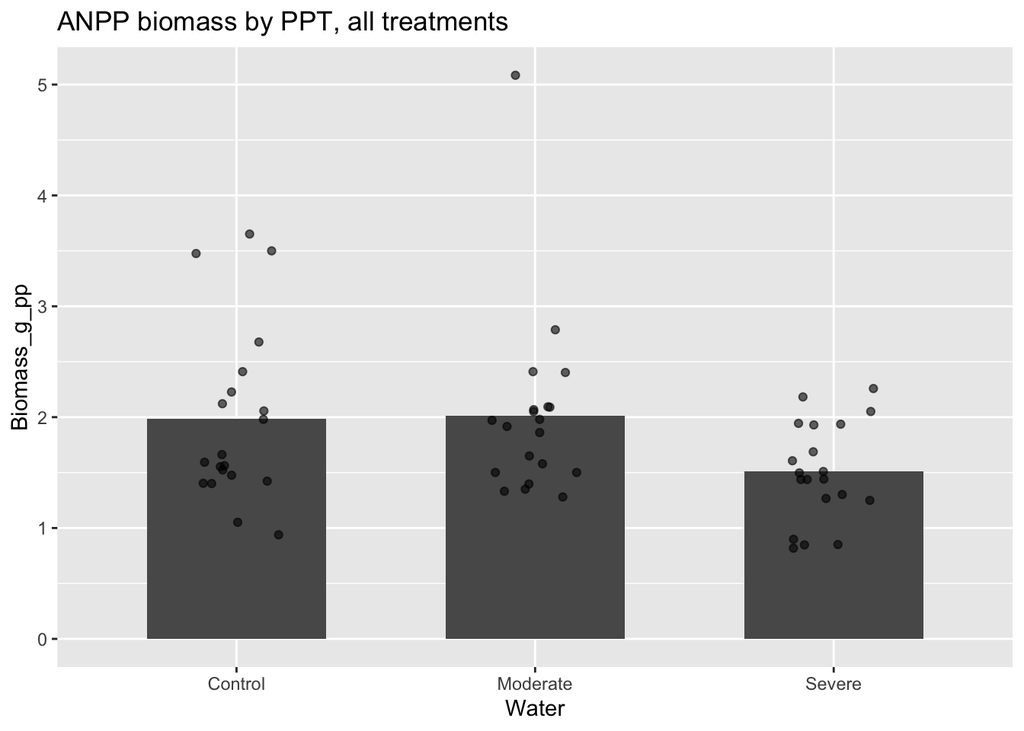

```r
# Bar graph looking at water with the individual points plotted on trop
ggplot(ANPP, aes(x = Water, y = Biomass_g_pp)) +
  stat_summary(fun = mean, geom = "col", width = 0.6) +
  geom_jitter(width = 0.15, alpha = 0.6) +
  ggtitle("ANPP biomass by PPT, all treatments")
```

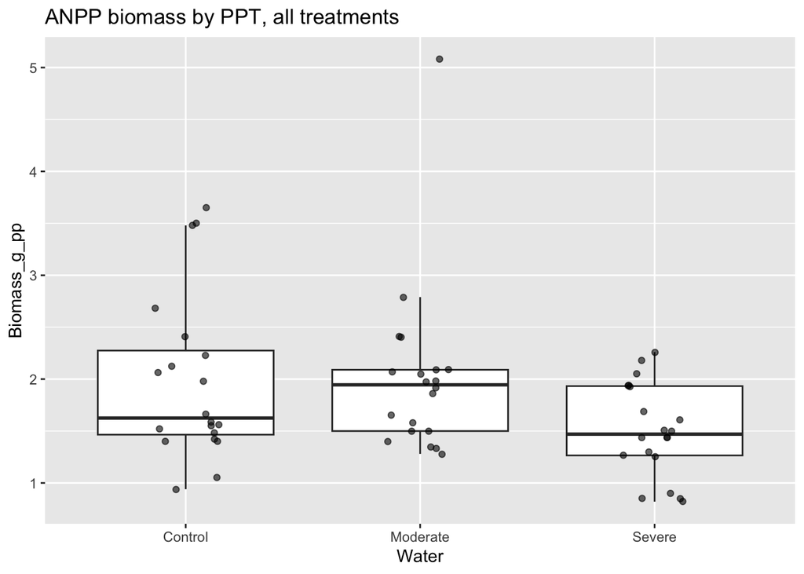

```r
# The same thing (kind of) but as a boxplot with the scattered points

#This code is redundant but good for copy paste later?
ANPP <- ANPP %>%
  mutate(
    Water = factor(Water, levels = c("Control", "Moderate", "Severe"))
  )

# The plot
ggplot(ANPP, aes(x = Water, y = Biomass_g_pp)) +
  geom_boxplot(outlier.shape = NA) +
  geom_jitter(width = 0.15, alpha = 0.6) +
  ggtitle("ANPP biomass by PPT, all treatments")
```

Takeaways

- There definitely seems to be some outlier activity going on
- Nothing really interesting oof

## Focusing on crop diversity: inter vs mono

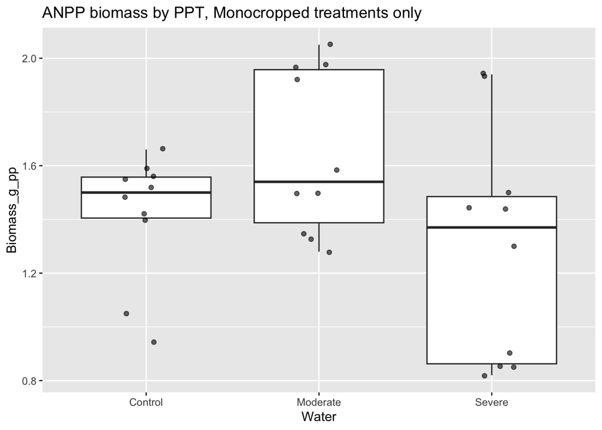

```r
# Looking at just monocropped

ANPP <- ANPP %>%
  mutate(
    Water = factor(Water, levels = c("Control", "Moderate", "Severe")),
    Inoculation = factor(Inoculation),
    Polyculture = factor(Polyculture)
  )

ANPP_inter <- ANPP %>%
  filter(Polyculture == "Mono")

ggplot(ANPP_inter, aes(x = Water, y = Biomass_g_pp)) +
  geom_boxplot(outlier.shape = NA) +
  geom_jitter(width = 0.15, alpha = 0.6) +
  ggtitle("ANPP biomass by PPT, Monocropped treatments only")
```

And looking at intercropped

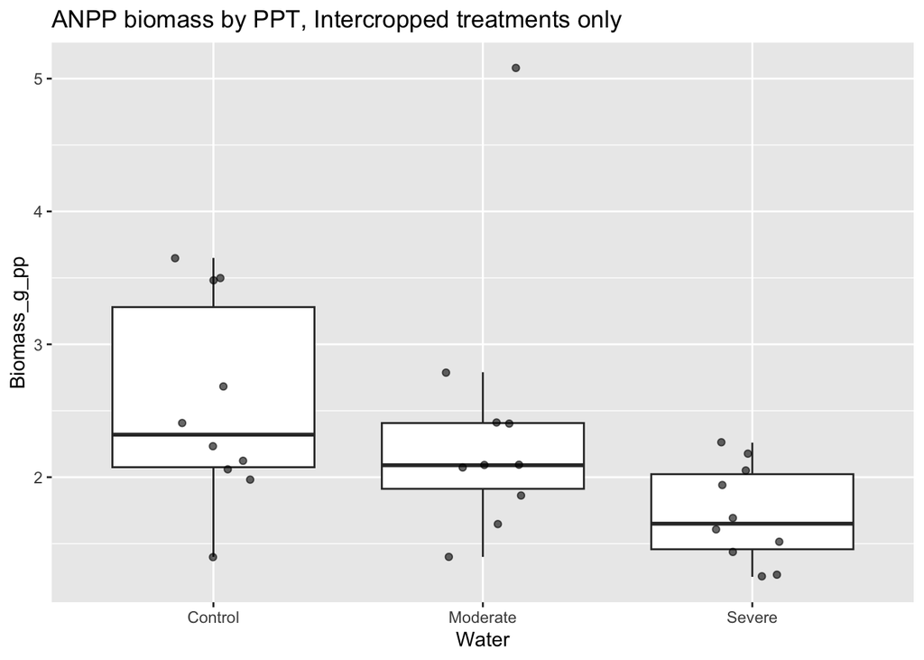

```r
# Looking at just intercropped

ANPP <- ANPP %>%
  mutate(
    Water = factor(Water, levels = c("Control", "Moderate", "Severe")),
    Inoculation = factor(Inoculation),
    Polyculture = factor(Polyculture)
  )

ANPP_inter <- ANPP %>%
  filter(Polyculture == "Inter")

ggplot(ANPP_inter, aes(x = Water, y = Biomass_g_pp)) +
  geom_boxplot(outlier.shape = NA) +
  geom_jitter(width = 0.15, alpha = 0.6) +
  ggtitle("ANPP biomass by PPT, Intercropped treatments only")
```

Let’s see that side by side and broken down by inoculation status as well

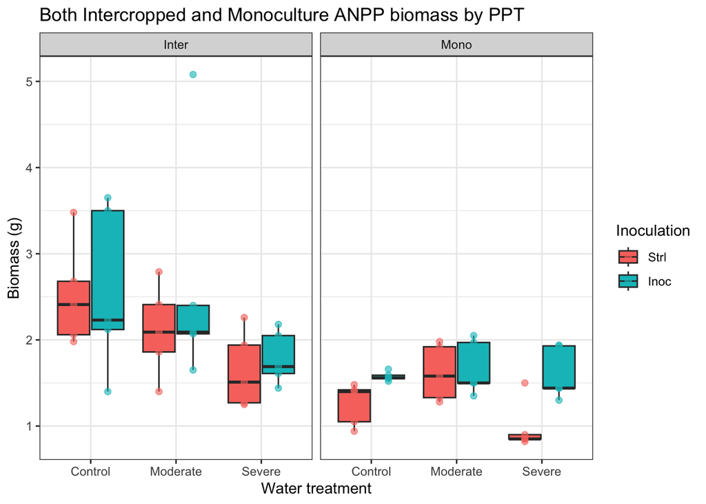

```r
# Splitting it by crop treatment

ANPP <- ANPP %>%
  mutate(
    Water       = factor(Water, levels = c("Control", "Moderate", "Severe")),
    Inoculation = factor(Inoculation, levels = c("Strl", "Inoc")),
    Polyculture = factor(Polyculture, levels = c("Inter", "Mono"))
  )

ggplot(ANPP, aes(x = Water, y = Biomass_g_pp, fill = Inoculation)) +
  geom_boxplot(
    outlier.shape = NA,
    position = position_dodge(width = 0.8)
  ) +
  geom_point(
    aes(color = Inoculation),
    alpha = 0.6,
    size = 1.8,
    position = position_dodge(width = 0.8)
  ) +
  facet_wrap(~ Polyculture) +
  theme_bw() +
  labs(
    x = "Water treatment",
    y = "Biomass (g)"
  ) +
  ggtitle("Both Intercropped and Monoculture ANPP biomass by PPT")
```

Takeaways

- These data seem totally all over the place
- Crazy tail activity
- Yeah

## ANPP statistics

To conclude my ANPP work, let’s generate some statistics

Before I begin I want to check some assumptions of a t-test

The boxes shouldn’t have overly long tails or outliers. The residuals should be straight.

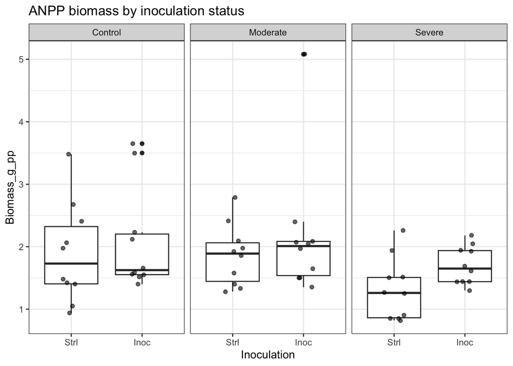

```r
# Check of distributions
ggplot(ANPP, aes(x = Inoculation, y = Biomass_g_pp)) +
  geom_boxplot() +
  geom_jitter(width = 0.15, alpha = 0.6) +
  facet_wrap(~ Water) +
  theme_bw() +
  ggtitle("ANPP biomass by inoculation status")
```

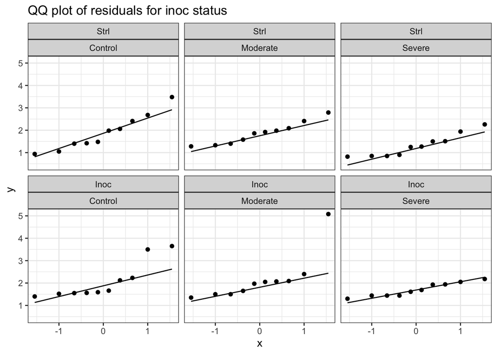

```r
# Q–Q plots of residuals
ggplot(ANPP, aes(sample = Biomass_g_pp)) +
  stat_qq() +
  stat_qq_line() +
  facet_wrap(~ Inoculation + Water) +
  theme_bw() +
  ggtitle("QQ plot of residuals for inoc status")
```

- The lines of residuals seem to have several significant outliers, especially the inoculated treatments

This next section is generating a variety of summary statistics about the data, and then saving them as CSVs.

```r
# Load + clean
ANPP <- ANPP %>%
  mutate(
    Inoculation = factor(Inoculation, levels = c("Strl", "Inoc")),
    Polyculture = factor(Polyculture, levels = c("Mono", "Inter")),
    Water = factor(Water, levels = c("Control", "Moderate", "Severe"))
  ) %>%
  filter(!is.na(Biomass_g_pp))

# Descriptive statistics
desc_stats <- function(x) {
  tibble(
    n      = sum(!is.na(x)),
    mean   = mean(x, na.rm = TRUE),
    sd     = sd(x, na.rm = TRUE),
    se     = sd(x, na.rm = TRUE) / sqrt(sum(!is.na(x))),
    median = median(x, na.rm = TRUE),
    q25    = quantile(x, 0.25, na.rm = TRUE, names = FALSE),
    q75    = quantile(x, 0.75, na.rm = TRUE, names = FALSE),
    iqr    = IQR(x, na.rm = TRUE),
    min    = min(x, na.rm = TRUE),
    max    = max(x, na.rm = TRUE)
  )
}

# Each of the 4 treatments within each Water level
summary_4treat_by_water <- ANPP %>%
  group_by(Water, Inoculation, Polyculture) %>%
  summarise(desc_stats(Biomass_g_pp), .groups = "drop")

# Inoculation only (fold inter/mono together), within each Water
summary_inoc_by_water <- ANPP %>%
  group_by(Water, Inoculation) %>%
  summarise(desc_stats(Biomass_g_pp), .groups = "drop")

# Polyculture only (fold inoc/strl together), within each Water
summary_poly_by_water <- ANPP %>%
  group_by(Water, Polyculture) %>%
  summarise(desc_stats(Biomass_g_pp), .groups = "drop")

# Oerall summaries across Water (all data)
summary_4treat_overall <- ANPP %>%
  group_by(Inoculation, Polyculture) %>%
  summarise(desc_stats(Biomass_g_pp), .groups = "drop")

summary_inoc_overall <- ANPP %>%
  group_by(Inoculation) %>%
  summarise(desc_stats(Biomass_g_pp), .groups = "drop")

summary_poly_overall <- ANPP %>%
  group_by(Polyculture) %>%
  summarise(desc_stats(Biomass_g_pp), .groups = "drop")


# Looking at them as tables
summary_4treat_by_water
```

```
## # A tibble: 12 × 13
##    Water    Inoculation Polyculture     n  mean     sd     se median   q25   q75
##    <fct>    <fct>       <fct>       <int> <dbl>  <dbl>  <dbl>  <dbl> <dbl> <dbl>
##  1 Control  Strl        Mono            5 1.26  0.245  0.110    1.4   1.05  1.42
##  2 Control  Strl        Inter           5 2.52  0.605  0.270    2.41  2.06  2.68
##  3 Control  Inoc        Mono            5 1.58  0.0532 0.0238   1.56  1.55  1.59
##  4 Control  Inoc        Inter           5 2.58  0.964  0.431    2.23  2.12  3.5
##  5 Moderate Strl        Mono            5 1.62  0.324  0.145    1.58  1.33  1.92
##  6 Moderate Strl        Inter           5 2.11  0.529  0.237    2.09  1.86  2.41
##  7 Moderate Inoc        Mono            5 1.67  0.314  0.140    1.5   1.5   1.97
##  8 Moderate Inoc        Inter           5 2.66  1.38   0.617    2.09  2.07  2.4
##  9 Severe   Strl        Mono            5 0.984 0.290  0.130    0.85  0.85  0.9
## 10 Severe   Strl        Inter           5 1.65  0.442  0.197    1.51  1.27  1.94
## 11 Severe   Inoc        Mono            5 1.61  0.302  0.135    1.44  1.44  1.93
## 12 Severe   Inoc        Inter           5 1.79  0.310  0.139    1.69  1.61  2.05
## # ℹ 3 more variables: iqr <dbl>, min <dbl>, max <dbl>
```

```r
summary_inoc_by_water
```

```
## # A tibble: 6 × 12
##   Water    Inoculation     n  mean    sd     se median   q25   q75   iqr   min
##   <fct>    <fct>       <int> <dbl> <dbl>  <dbl>  <dbl> <dbl> <dbl> <dbl> <dbl>
## 1 Control  Strl           10  1.89 0.796 0.252    1.73 1.40   2.32 0.918  0.94
## 2 Control  Inoc           10  2.08 0.833 0.264    1.62 1.55   2.20 0.650  1.4
## 3 Moderate Strl           10  1.86 0.488 0.154    1.89 1.44   2.06 0.618  1.28
## 4 Moderate Inoc           10  2.17 1.08  0.340    2.01 1.54   2.08 0.547  1.35
## 5 Severe   Strl           10  1.32 0.496 0.157    1.26 0.862  1.51 0.645  0.82
## 6 Severe   Inoc           10  1.70 0.304 0.0963   1.65 1.44   1.94 0.498  1.3
## # ℹ 1 more variable: max <dbl>
```

```r
summary_poly_by_water
```

```
## # A tibble: 6 × 12
##   Water    Polyculture     n  mean    sd     se median   q25   q75   iqr   min
##   <fct>    <fct>       <int> <dbl> <dbl>  <dbl>  <dbl> <dbl> <dbl> <dbl> <dbl>
## 1 Control  Mono           10  1.42 0.237 0.0748   1.5  1.40   1.56 0.153  0.94
## 2 Control  Inter          10  2.55 0.759 0.240    2.32 2.08   3.28 1.20   1.4
## 3 Moderate Mono           10  1.65 0.302 0.0956   1.54 1.39   1.96 0.57   1.28
## 4 Moderate Inter          10  2.38 1.03  0.325    2.09 1.91   2.41 0.495  1.4
## 5 Severe   Mono           10  1.30 0.432 0.137    1.37 0.862  1.48 0.622  0.82
## 6 Severe   Inter          10  1.72 0.368 0.116    1.65 1.46   2.02 0.565  1.25
## # ℹ 1 more variable: max <dbl>
```

```r
# Saving these as csvs

write.csv(summary_4treat_by_water,
          file.path(("Biomass/ANPP"), "summary_4treat_by_water.csv"),
          row.names = FALSE)

write.csv(summary_inoc_by_water,
          file.path(("Biomass/ANPP"), "summary_inoc_by_water.csv"),
          row.names = FALSE)

write.csv(summary_poly_by_water,
          file.path(("Biomass/ANPP"), "summary_poly_by_water.csv"),
          row.names = FALSE)

write.csv(summary_4treat_overall,
          file.path(("Biomass/ANPP"), "summary_4treat_overall.csv"),
          row.names = FALSE)

write.csv(summary_inoc_overall,
          file.path(("Biomass/ANPP"), "summary_inoc_overall.csv"),
          row.names = FALSE)

write.csv(summary_poly_overall,
          file.path(("Biomass/ANPP"), "summary_poly_overall.csv"),
          row.names = FALSE)
```

## ANPP statistical analysis

I used AI to generate stats. This should be verified for sure!! Especially to make sure I meet the assumptions to even be using these stats.

```r
# These statistics were Chat GPT and should be verified

# P-VALUES: Simple comparisons within each Water ----
# Welch t-tests are robust to unequal variances (default in t.test)

# a) Inoculation effect within each Water (folding Polyculture)
ttest_inoc_within_water <- ANPP %>%
  group_by(Water) %>%
  do(tidy(t.test(Biomass_g_pp ~ Inoculation, data = .))) %>%
  ungroup() %>%
  select(Water, estimate1, estimate2, statistic, p.value, conf.low, conf.high, method)

# b) Polyculture effect within each Water (folding Inoculation)
ttest_poly_within_water <- ANPP %>%
  group_by(Water) %>%
  do(tidy(t.test(Biomass_g_pp ~ Polyculture, data = .))) %>%
  ungroup() %>%
  select(Water, estimate1, estimate2, statistic, p.value, conf.low, conf.high, method)

# ---- 3-way factorial model (lets you test interactions) ----
# If your data are fairly normal-ish, this is a strong default.
fit_aov <- aov(Biomass_g_pp ~ Inoculation * Polyculture * Water, data = ANPP)
aov_table <- broom::tidy(fit_aov)

# ---- Optional: Nonparametric alternatives (in case assumptions are shaky) ----
# Wilcoxon rank-sum within each Water for Inoculation / Polyculture
wilcox_inoc_within_water <- ANPP %>%
  group_by(Water) %>%
  do(tidy(wilcox.test(Biomass_g_pp ~ Inoculation, data = ., exact = FALSE))) %>%
  ungroup() %>%
  select(Water, statistic, p.value, method)

wilcox_poly_within_water <- ANPP %>%
  group_by(Water) %>%
  do(tidy(wilcox.test(Biomass_g_pp ~ Polyculture, data = ., exact = FALSE))) %>%
  ungroup() %>%
  select(Water, statistic, p.value, method)

# Print these

ttest_inoc_within_water
```

```
## # A tibble: 3 × 8
##   Water    estimate1 estimate2 statistic p.value conf.low conf.high method
##   <fct>        <dbl>     <dbl>     <dbl>   <dbl>    <dbl>     <dbl> <chr>
## 1 Control       1.89      2.08    -0.516  0.612    -0.954   0.578   Welch Two S…
## 2 Moderate      1.86      2.17    -0.808  0.434    -1.11    0.509   Welch Two S…
## 3 Severe        1.32      1.70    -2.10   0.0528   -0.779   0.00526 Welch Two S…
```

```r
ttest_poly_within_water
```

```
## # A tibble: 3 × 8
##   Water    estimate1 estimate2 statistic  p.value conf.low conf.high method
##   <fct>        <dbl>     <dbl>     <dbl>    <dbl>    <dbl>     <dbl> <chr>
## 1 Control       1.42      2.55     -4.51 0.000944   -1.69    -0.579  Welch Two …
## 2 Moderate      1.65      2.38     -2.18 0.0528     -1.49     0.0109 Welch Two …
## 3 Severe        1.30      1.72     -2.36 0.0303     -0.801   -0.0452 Welch Two …
```

```r
aov_table
```

```
## # A tibble: 8 × 6
##   term                             df   sumsq meansq statistic     p.value
##   <chr>                         <dbl>   <dbl>  <dbl>     <dbl>       <dbl>
## 1 Inoculation                       1  1.28   1.28      3.65    0.0620
## 2 Polyculture                       1  8.78   8.78     25.0     0.00000804
## 3 Water                             2  3.22   1.61      4.59    0.0150
## 4 Inoculation:Polyculture           1  0.0252 0.0252    0.0718  0.790
## 5 Inoculation:Water                 2  0.0997 0.0499    0.142   0.868
## 6 Polyculture:Water                 2  1.27   0.635     1.81    0.175
## 7 Inoculation:Polyculture:Water     2  0.647  0.324     0.922   0.405
## 8 Residuals                        48 16.8    0.351    NA      NA
```

```r
# Saving as CSV

write.csv(ttest_inoc_within_water,
          file.path(("Biomass/ANPP/Stats"), "ttest_inoc_within_water.csv"),
          row.names = FALSE)

write.csv(ttest_poly_within_water,
          file.path(("Biomass/ANPP/Stats"), "ttest_poly_within_water.csv"),
          row.names = FALSE)

write.csv(aov_table,
          file.path(("Biomass/ANPP/Stats"), "anova_3way_table.csv"),
          row.names = FALSE)

write.csv(wilcox_inoc_within_water,
          file.path(("Biomass/ANPP/Stats"), "wilcox_inoc_within_water.csv"),
          row.names = FALSE)

write.csv(wilcox_poly_within_water,
          file.path(("Biomass/ANPP/Stats"), "wilcox_poly_within_water.csv"),
          row.names = FALSE)
```